# Experiment Report

This report presents the analysis for **task_2_specific_model**: Train and evaluate a model on Task 2.

Mon Dec 30 23:04:13 2024

## Description of the data

### Responses excluded due to non-numeric feature values or scores

**Training set**

Total number of excluded responses: 0 (0.0% of the original 1206)

**Evaluation set**

Total number of excluded responses: 0 (0.0% of the original 594)

The rest of this report is based only on the responses that were not excluded above.

Composition of the training and evaluation sets

| partition | responses |
| --- | --- |
| Training | 1206 |
| Evaluation | 594 |
| Overlapping | 0 |
| Total | 1800 |

Total number of double scored responses in the evaluation set used: 594 (zeros excluded)

## Overall descriptive feature statistics

These values are reported before transformations.

|  | mean | std. dev. | min | max | skewness | kurtosis | Correlation | p | N |
| --- | --- | --- | --- | --- | --- | --- | --- | --- | --- |
| %MISSPELLED | 0.026 | 0.026 | 0.000 | 0.258 | 2.418 | 13.378 | -0.454 | 0.000 | 1206 |
| AVG_WLEN | 4.271 | 0.253 | 3.245 | 5.114 | -0.029 | 3.281 | 0.296 | 0.000 | 1206 |
| LOGTYPES | 2.172 | 0.157 | 1.342 | 2.574 | -1.110 | 5.914 | 0.718 | 0.000 | 1206 |
| LOGWORDS | 2.580 | 0.212 | 1.531 | 3.067 | -1.265 | 6.038 | 0.710 | 0.000 | 1206 |

### Prevalence of recoded cases

This sections shows the number and percentage of cases truncated to mean +/- 4 SD for each feature.

[figure not shown]

### Feature value distribution

The following table shows additional statistics for the data. Quantiles are computed using type=3 method used in SAS. The mild outliers are defined as data points between [1.5, 3) * IQR away from the nearest quartile. Extreme outliers are the data points >= 3 * IQR away from the nearest quartile.

|  | 1% | 5% | 25% | 50% | 75% | 95% | 99% | IQR | Mild outliers | Extreme outliers |
| --- | --- | --- | --- | --- | --- | --- | --- | --- | --- | --- |
| %MISSPELLED | 0.000 | 0.002 | 0.009 | 0.019 | 0.036 | 0.078 | 0.111 | 0.027 | 61 | 8 |
| AVG_WLEN | 3.694 | 3.856 | 4.100 | 4.280 | 4.431 | 4.687 | 4.870 | 0.330 | 13 | 0 |
| LOGTYPES | 1.643 | 1.898 | 2.093 | 2.190 | 2.270 | 2.391 | 2.459 | 0.176 | 28 | 10 |
| LOGWORDS | 1.806 | 2.176 | 2.487 | 2.610 | 2.714 | 2.855 | 2.961 | 0.227 | 41 | 12 |

## Feature distributions and inter-feature correlations

### Training set distributions

The following plot shows the distributions of the feature values in the training set, after transformation (if applicable), truncation and standardization (if applicable). The line shows the kernel density estimate. The human score (`sc1`) is also included.

Response length (`length`) is included if you specified `length_column` in the config file, unless the column had missing values or a standard deviation <= 0.

[figure not shown]

### Inter-feature correlations

The following table shows the Pearson correlations between all the training features after transformation (if applicable), truncation and standardization (if applicable). The human score (`sc1`) is also included.

Response length (`length`) is included if you specified `length_column` in the config file, unless the column had missing values or a standard deviation <= 0.

The following values are highlighted:

- inter-feature correlations above 0.7, and
- `sc1`-feature correlations lower than 0.1 or higher than 0.7

|  | sc1 | %MISSPELLE D | AVG_WLEN | LOGTYPES | LOGWORDS |
| --- | --- | --- | --- | --- | --- |
| sc1 | 1.000 | 0.456 | 0.296 | 0.718 | 0.711 |
| %MISSPELLED | 0.456 | 1.000 | 0.180 | 0.381 | 0.423 |
| AVG_WLEN | 0.296 | 0.180 | 1.000 | 0.165 | 0.082 |
| LOGTYPES | 0.718 | 0.381 | 0.165 | 1.000 | 0.951 |
| LOGWORDS | 0.711 | 0.423 | 0.082 | 0.951 | 1.000 |

### Marginal and partial correlations

The plot below shows correlations between truncated and standardized (if applicable) values of each feature against human score. The first bar (`Marginal`) in each case shows Pearson's correlation. The second bar (`Partial - all`) shows partial correlations after controlling for all other variables. If you specified `length_column` in the config file, a third bar (`Partial - length`) will show partial correlations of each feature against the human score after controlling for length. The dotted lines correspond to *r* = 0.1 and *r* = 0.7.

[figure not shown]

Consistency

*Note: this section assumes that the score used for evaluating machine scores is the score assigned by the first rater.*

Human-human agreement

This table shows the human-human agreement on the double-scored evaluation data. The following are highlighted :

- Exact agreement (`exact_agr`) < 50%

- Adjacent agreement (`adj_agr`) < 95%

- Quadratic weighted kappa (`wtkappa`) < 0.7

- Pearson correlation (`corr`) < 0.7

| N | h1_mean | h1_sd | h1_min | h1_max | h2_mean | h2_sd | h2_min | h2_max | corr | wtkappa | kappa | exact_agr | adj_agr | SMD |
| --- | --- | --- | --- | --- | --- | --- | --- | --- | --- | --- | --- | --- | --- | --- |
| 594 | 3.434 | 0.775 | 1.000 | 6.000 | 3.424 | 0.776 | 1.000 | 6.000 | 0.795 | 0.795 | 0.623 | 76.431 | 99.663 | -0.013 |

Degradation

The next table shows the degradation in the evaluation metrics (`diff`) when comparing the machine (`H-M`) to a second human (`H-H`). A positive degradation value indicates better human-machine performance. Note that the human-machine agreement is computed on the full dataset (to get a reliable estimate) whereas the human-human agreement is computed on the subset of responses that were double-scored.

The following degradation values are highlighted

- `corr` < -0.1

- `wtkappa` < -0.1

|  |  | corr | kappa | wtkappa | exact_agr | adj_agr | SMD |
| --- | --- | --- | --- | --- | --- | --- | --- |
| raw | H-H | 0.795 | 0.623 | 0.795 | 76.431 | 99.663 | -0.013 |
|  | H-M | 0.767 | 0.472 | 0.744 | 0.000 | 96.801 | -0.034 |
|  | diff | -0.028 | -0.151 | -0.052 | -76.431 | -2.862 | -0.021 |
| raw_trim | H-H | 0.795 | 0.623 | 0.795 | 76.431 | 99.663 | -0.013 |
|  | H-M | 0.767 | 0.472 | 0.744 | 0.000 | 96.801 | -0.034 |
|  | diff | -0.028 | -0.151 | -0.052 | -76.431 | -2.862 | -0.021 |
| raw_trim_round | H-H | 0.795 | 0.623 | 0.795 | 76.431 | 99.663 | -0.013 |
|  | H-M | 0.684 | 0.472 | 0.676 | 68.350 | 99.158 | -0.050 |
|  | diff | -0.112 | -0.151 | -0.119 | -8.081 | -0.505 | -0.037 |
| scale | H-H | 0.795 | 0.623 | 0.795 | 76.431 | 99.663 | -0.013 |
|  | H-M | 0.767 | 0.459 | 0.767 | 0.000 | 94.949 | -0.034 |
|  | diff | -0.028 | -0.164 | -0.029 | -76.431 | -4.714 | -0.021 |
| scale_trim | H-H | 0.795 | 0.623 | 0.795 | 76.431 | 99.663 | -0.013 |
|  | H-M | 0.767 | 0.462 | 0.767 | 0.000 | 94.949 | -0.032 |
|  | diff | -0.028 | -0.161 | -0.028 | -76.431 | -4.714 | -0.019 |
| scale_trim_round | H-H | 0.795 | 0.623 | 0.795 | 76.431 | 99.663 | -0.013 |
|  | H-M | 0.728 | 0.462 | 0.726 | 65.993 | 99.495 | -0.033 |
|  | diff | -0.067 | -0.161 | -0.069 | -10.438 | -0.168 | -0.020 |

Human-human confusion matrix

Confusion matrix using the two human scores (rows=human #1, columns=human #2). Note that the matrix is computed on the subset of responses that were double-scored.

|  | 1 | 2 | 3 | 4 | 5 | 6 |
| --- | --- | --- | --- | --- | --- | --- |
| 1 | 6 | 2 | 0 | 0 | 0 | 0 |
| 2 | 2 | 34 | 12 | 1 | 0 | 0 |
| 3 | 0 | 14 | 189 | 41 | 0 | 0 |
| 4 | 0 | 0 | 48 | 207 | 10 | 0 |
| 5 | 0 | 0 | 0 | 7 | 18 | 1 |
| 6 | 0 | 0 | 0 | 1 | 1 | 0 |

Disattenuated correlations

The next table shows the correlations between human and machine scores, the correlations between two human scores, and disattenuated correlations between human and machine scores computed as human-machine correlations divided by the square root of human-human correlation. Note that the human-machine correlation is computed on the full dataset (to get a reliable estimate) whereas the human-human correlation is computed on the subset of responses that were double-scored.

The following values are highlighted

- `disattenuated_corr` < 0.9

|  | corr_HM | corr_HH | sqrt_HH | corr_disattenuated |
| --- | --- | --- | --- | --- |
| raw | 0.767 | 0.795 | 0.892 | 0.860 |
| raw_trim | 0.767 | 0.795 | 0.892 | 0.860 |
| raw_trim_round | 0.684 | 0.795 | 0.892 | 0.767 |
| scale | 0.767 | 0.795 | 0.892 | 0.860 |
| scale_trim | 0.767 | 0.795 | 0.892 | 0.860 |
| scale_trim_round | 0.728 | 0.795 | 0.892 | 0.817 |

## Model

Model used: **LinearRegression**

Number of features in model: **4**

Model summary

```
                            OLS Regression Results
==============================================================================
Dep. Variable:                    sc1   R-squared:                       0.588
Model:                            OLS   Adj. R-squared:                  0.587
Method:                 Least Squares   F-statistic:                     429.4
Date:                Mon, 30 Dec 2024   Prob (F-statistic):          9.75e-230
Time:                        23:04:09   Log-Likelihood:                -867.23
No. Observations:                1206   AIC:                             1744.
Df Residuals:                    1201   BIC:                             1770.
Df Model:                           4
Covariance Type:            nonrobust
===============================================================================
                  coef    std err          t      P>|t|      [0.025      0.975]
-------------------------------------------------------------------------------
const           3.4063      0.014    237.680      0.000       3.378       3.434
%MISSPELLED     0.1275      0.016      7.889      0.000       0.096       0.159
AVG_WLEN        0.1457      0.015      9.543      0.000       0.116       0.176
LOGTYPES        0.2402      0.049      4.944      0.000       0.145       0.335
LOGWORDS        0.2562      0.049      5.198      0.000       0.159       0.353
==============================================================================
Omnibus:                        5.411   Durbin-Watson:                   2.005
Prob(Omnibus):                  0.067   Jarque-Bera (JB):                6.015
Skew:                          -0.085   Prob(JB):                       0.0494
Kurtosis:                       3.301   Cond. No.                         7.18
==============================================================================

Notes:
[1] Standard Errors assume that the covariance matrix of the errors is correctly specified.
```

Model fit

| N responses | N features | R2 | R2_adjusted |
| --- | --- | --- | --- |
| 1206 | 4 | 0.588 | 0.587 |

### Standardized and relative regression coefficients (betas)

The relative coefficients are intended to show relative contribution of different feature and their primary purpose is to indentify whether one of the features has an unproportionate effect over the final score. They are computed as standardized/(sum of absolute values of standardized coefficients).

Negative standardized coefficients are highlighted.

**Note**: if the model contains negative coefficients, relative values will not sum up to one and their interpretation is generally questionable.

| feature | standardized | relative |
| --- | --- | --- |
| %MISSPELLED | 0.165 | 0.166 |
| AVG_WLEN | 0.188 | 0.189 |
| LOGTYPES | 0.310 | 0.312 |
| LOGWORDS | 0.331 | 0.333 |

Here are the same values, shown graphically.

[figure not shown]

Model diagnostics

These are standard plots for model diagnostics for the main model. All information is computed based on the training set.

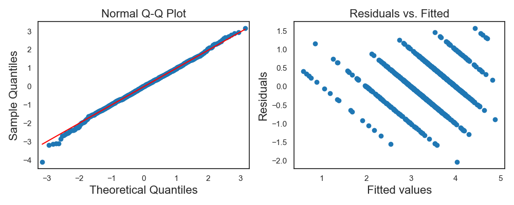

## Evaluation results

### Overall association statistics

The tables in this section show the standard association metrics between *observed* human scores and different types of machine scores. These results are computed on the evaluation set. `raw_trim` scores are truncated to [0.5002, 6.4998000000000005]. `raw_trim_round` scores are computed by first truncating and then rounding the predicted score. Scaled scores are computed by re-scaling the predicted scores using mean and standard deviation of human scores as observed on the training data and mean and standard deviation of machine scores as predicted for the training set.

#### Descriptive holistic score statistics

The table shows distributional properties of human and system scores. SMD values lower then -0.15 or higher than 0.15 are highlighted.

*Please note that for raw scores, SMD values are likely to be affected by possible differences in scale.*

|  | N | h_mean | sys_mean | h_sd | sys_sd | h_min | sys_min | h_max | sys_max | SMD |
| --- | --- | --- | --- | --- | --- | --- | --- | --- | --- | --- |
| raw | 594 | 3.434 | 3.408 | 0.775 | 0.604 | 1.000 | 0.826 | 6.000 | 4.717 | -0.034 |
| raw_trim | 594 | 3.434 | 3.408 | 0.775 | 0.604 | 1.000 | 0.826 | 6.000 | 4.717 | -0.034 |
| raw_trim_round | 594 | 3.434 | 3.396 | 0.775 | 0.675 | 1.000 | 1.000 | 6.000 | 5.000 | -0.050 |
| scale | 594 | 3.434 | 3.408 | 0.775 | 0.788 | 1.000 | 0.043 | 6.000 | 5.115 | -0.034 |
| scale_trim | 594 | 3.434 | 3.409 | 0.775 | 0.784 | 1.000 | 0.500 | 6.000 | 5.115 | -0.032 |
| scale_trim_round | 594 | 3.434 | 3.409 | 0.775 | 0.835 | 1.000 | 1.000 | 6.000 | 5.000 | -0.033 |

#### Association statistics

The table shows the standard association metrics between human scores and machine scores. Note that for computation of `kappa` all machine scores are rounded.

|  | N | corr | wtkappa | R2 | kappa | exact_agr | adj_agr | RMSE |
| --- | --- | --- | --- | --- | --- | --- | --- | --- |
| raw | 594 | 0.767 | 0.744 | 0.587 | 0.472 | 0.000 | 96.801 | 0.497 |
| raw_trim | 594 | 0.767 | 0.744 | 0.587 | 0.472 | 0.000 | 96.801 | 0.497 |
| raw_trim_round | 594 | 0.684 | 0.676 | 0.430 | 0.472 | 68.350 | 99.158 | 0.585 |
| scale | 594 | 0.767 | 0.767 | 0.525 | 0.459 | 0.000 | 94.949 | 0.533 |
| scale_trim | 594 | 0.767 | 0.767 | 0.528 | 0.462 | 0.000 | 94.949 | 0.532 |
| scale_trim_round | 594 | 0.728 | 0.726 | 0.407 | 0.462 | 65.993 | 99.495 | 0.596 |

### Confusion matrix

Confusion matrix using raw, trimmed, and rounded scores and human scores (rows=human, columns=system).

|  | 1 | 2 | 3 | 4 | 5 | 6 |
| --- | --- | --- | --- | --- | --- | --- |
| 1 | 4 | 1 | 3 | 0 | 0 | 0 |
| 2 | 4 | 26 | 19 | 0 | 0 | 0 |
| 3 | 0 | 11 | 175 | 58 | 0 | 0 |
| 4 | 0 | 0 | 64 | 200 | 1 | 0 |
| 5 | 0 | 0 | 0 | 25 | 1 | 0 |
| 6 | 0 | 0 | 0 | 2 | 0 | 0 |

### Distribution of human and machine scores

The histogram and the table below show the distibution of human scores and raw, trimmed, and rounded machine scores (as % of all responses). Differences in the table between human and machine distributions larger than 5 percentage points are highlighted.

[figure not shown]

| score | human | sys_raw | difference |
| --- | --- | --- | --- |
| 1.0 | 1.346801 | 1.346801 | 0.000 |
| 2.0 | 8.249158 | 6.397306 | -1.852 |
| 3.0 | 41.077441 | 43.939394 | 2.862 |
| 4.0 | 44.612795 | 47.979798 | 3.367 |
| 5.0 | 4.377104 | 0.336700 | -4.040 |
| 6.0 | 0.336700 | 0.000000 | -0.337 |

True score evaluations

The tables in this section show how well system scores can predict *true* scores. According to Test theory, a *true* score is a score that would have been obtained if there were no errors in measurement. While true scores cannot be observed, the variance of true scores and the prediction error can be estimated using observed human scores when multiple human ratings are available for a subset of responses. In this notebook the variance of true scores is estimated using the human ratings available for responses in the evaluation set. Note that the analyses in this section assume that the values in `test_label_column` and `second_human_score_column` are independent scores from different raters or groups of raters. These analyses are not applicable to a situation where `test_label_column` contains an average score from multiple raters

Variance of human scores

The table below shows variance of both sets of human scores for the whole evaluation set and for the subset of responses that were double-scored. Large differences in variance between the two human scores require further investigation.

|  | N_total | N_double | h1_var (single) | h1_var (double) | h2_var (double) |
| --- | --- | --- | --- | --- | --- |
| human | 594.000 | 594 | 0.600 | 0.600 | 0.602 |

Proportional reduction in mean squared error (PRMSE)

The table shows estimated variance of human rater errors, true score variance, mean squared error (MSE) and proportional reduction in mean squared error (PRMSE) for predicting a true score with system score. As for other evaluations, these results are computed on the evaluation set. `raw_trim` scores are truncated to [0.5002, 6.4998000000000005]. `raw_trim_round` scores are computed by first truncating and then rounding the predicted score. Scaled scores are computed by re-scaling the predicted scores using mean and standard deviation of human scores as observed on the training data and mean and standard deviation of machine scores as predicted for the training set.

|  | N | N raters | N single | N multiple | Variance of errors | True score var | MSE true | PRMSE true |
| --- | --- | --- | --- | --- | --- | --- | --- | --- |
| raw | 594 | 2 | 0 | 594 | 0.123 | 0.478 | 0.120 | 0.749 |
| scale | 594 | 2 | 0 | 594 | 0.123 | 0.478 | 0.155 | 0.675 |
| raw_trim | 594 | 2 | 0 | 594 | 0.123 | 0.478 | 0.120 | 0.749 |
| raw_trim_round | 594 | 2 | 0 | 594 | 0.123 | 0.478 | 0.202 | 0.578 |
| scale_trim | 594 | 2 | 0 | 594 | 0.123 | 0.478 | 0.154 | 0.678 |
| scale_trim_round | 594 | 2 | 0 | 594 | 0.123 | 0.478 | 0.210 | 0.560 |

## Principal component analysis

PCA using scaled data and singular value decomposition. This is computed using processed features after the truncation of outliers and other transformations specified in feature config file.

|  | PC1 | PC2 | PC3 | PC4 |
| --- | --- | --- | --- | --- |
| %MISSPELLED | -0.426 | 0.215 | -0.878 | -0.048 |
| AVG_WLEN | -0.184 | 0.929 | 0.313 | 0.068 |
| LOGTYPES | -0.626 | -0.173 | 0.300 | -0.699 |
| LOGWORDS | -0.627 | -0.245 | 0.205 | 0.710 |

|  | PC1 | PC2 | PC3 | PC4 |
| --- | --- | --- | --- | --- |
| Cumulative percentage of variance | 0.565 | 0.812 | 0.989 | 1.000 |
| Eigenvalues | 2.260 | 0.989 | 0.707 | 0.044 |
| Percentage of variance | 0.565 | 0.247 | 0.177 | 0.011 |

[figure not shown]

## Links to intermediate files

The following intermediate files were generated as part of this experiment.To examine a file, click on the link. Note that the descriptions provided here are only brief summaries. For more detailed descriptions, please refer to the [relevant RSMTool documentation](https://rsmtool.readthedocs.io/en/main/usage_rsmtool.html#intermediate-files).

| Filename | Description |
| --- | --- |
| betas | Standardized & relative regression coefficients |
| coefficients | Feature coefficients (including intercept) |
| coefficients_scaled | Scaled feature coefficients (including intercept) |
| confMatrix | Confusion matrix between human scores and machine scores |
| confMatrix_h1h2 | Confusion matrix between human-human scores |
| consistency | Human-human agreement metrics |
| cors_orig | Correlations between raw features & between features and human score |
| cors_processed | Correlations between pre-processed features & between features and human score |
| data_composition | Data composition statistics |
| degradation | Degradation in H-M performance compared to H-H |
| disattenuated_correlations | Disattenuated correlations between various scores |
| eval | Full set of evaluation metrics |
| eval_short | Subset of more commonly used evaluation metrics |
| feature | Feature values, signs, and transforms used in the final model |
| feature_descriptives | Main Descriptive statistics for raw feature values |
| feature_descriptivesExtra | Additional descriptive statistics for raw feature values |
| feature_outliers | Number and percentage of outliers trunctated during feature pre-processing |
| margcor_score_all_data | Marginal correlations between each pre-processed feature and human score |
| model_fit | R^2 and adjusted R^2 computed on the training set |
| pca | Results of principal components analysis on the pre-processed feature values |
| pcavar | Eigenvalues and variance explained by each principal component |
| pcor_score_all_data | Partial correlations between each pre-processed feature & human score, controlling for other features |
| postprocessing_params | Parameters used for trimming and scaling predicted scores |
| pred_processed | Predicted scores for the evaluation set |
| pred_train | Predicted scores for the training set |
| score_dist | Distributions of human and machine scores |
| test_excluded_composition | Composition of evaluation set responses excluded from analysis |
| test_features | Raw feature values for the evaluation set |
| test_human_scores | Human scores for the evaluation set |
| test_metadata | Metadata columns for the evaluation set |
| test_other_columns | Unused columns for the evaluation set |
| test_preprocessed_features | Pre-processed feature values for the evaluation set |
| train_excluded_composition | Composition of training set responses excluded from analysis |
| train_features | Raw feature values for the training set |
| train_metadata | Metadata columns for the training set |
| train_other_columns | Unused columns for the training set |
| train_preprocessed_features | Pre-processed feature values for the training set |
| true_score_eval | Metrics evaluating how well system scores predict true scores |

## System information

This report was generated using rsmtool v12.0.0 on a 64bit computer running Mac OS X.

### Python packages

[output not shown]

[output cut: 114 more lines]

[output not shown]